# Enrollment_Prediction

Huy

2024-11-01

# I. Installing All The Necessary Libraries

I first install and load the necessary libraries. These libraries are used for various purposes such as data manipulation, visualization, and building machine learning models:

- tidymodels: for building and tuning machine learning models.
- tidyverse: a collection of R packages for data manipulation and visualization.
- skimr: provides descriptive statistics in a clean and readable format.
- corrplot: for visualizing correlation matrices.
- GGally: extends ggplot2 with additional visualization options.
- themis: addresses class imbalance in datasets.
- rpart.plot: visualizes decision trees.
- xgboost: for gradient boosting machine learning models.
- lubridate: simplifies date and time manipulations.
- ggridges: creates ridge plots for data visualization.
- DescTools: provides additional descriptive statistics functions.
- NbClust: for cluster analysis.
- ggdendro: visualizes hierarchical clustering results.
- klaR: for classification tasks.
- glmnet: implements regularized regression techniques (LASSO, Ridge).
- doParallel: enables parallel processing.
- ranger: implements random forests efficiently.

```r
#install.packages("tidymodels")
library(tidymodels)
#install.packages("tidyverse")
library(tidyverse)
```

```r
#install.packages("skimr")
library(skimr)

#install.packages("corrplot")
library(corrplot)
#install.packages("GGally")
library(GGally)
#install.packages("themis")
library(themis)

#install.packages("rpart.plot")
library(rpart.plot)
#install.packages("xgboost")
library(xgboost)
#install.packages("lubridate")
library(lubridate)

#install.packages("ggridges")
library(ggridges)

#install.packages("DescTools")
library(DescTools)

#install.packages("NbClust")
library(NbClust)

#install.packages("ggdendro")
library(ggdendro)

#install.packages("klaR")
library(klaR)
#install.packages("glmnet")
library(glmnet)
#install.packages("doParallel")
library(doParallel)
#install.packages("ranger")
library(ranger)
```

# II. Loading The Dataset and Pre-built Functions

```r
# load the censored dataset and helper functions
load("./offers_censored.RData")
source("./helpful_functions.R")
```

```r
# display the first few rows of the censored dataset
head(offers)
```

```
## # A tibble: 6 × 18
##   Status AppYear Program AppDate    OfferDate  ResponseDate Response Demo1 Demo2
##   <fct>    <int> <fct>   <date>     <date>     <date>       <fct>    <fct> <fct>
## 1 Enrol…    2020 MScBA-… 2019-10-01 2019-10-01 2020-05-02   Accepted U     W
## 2 Not e…    2020 MScBA-… 2019-10-01 2019-10-01 NA           Unknown  U     X
## 3 Not e…    2020 MScBA-… 2019-10-01 2019-10-01 NA           Unknown  V     W
## 4 Enrol…    2020 MScBA-… 2019-10-01 2019-10-10 2019-10-11   Accepted U     Y
## 5 Enrol…    2020 MScBA-… 2019-10-01 2019-10-15 2019-10-15   Accepted V     Y
## 6 Enrol…    2020 MScBA-… 2019-10-01 2020-03-03 2020-03-03   Accepted U     Y
## # ℹ 9 more variables: Demo3 <fct>, Edu1 <fct>, Edu2 <fct>, Edu3 <fct>,
## #   App1 <fct>, App2 <fct>, App3 <fct>, App4 <int>, HowFirstHeard <fct>
```

# III. Analysis, Assessment, Final Training, and Prediction Sets

## Final Training Set and Prediction Set

The prediction set includes AY2023 observations that were available before 2023-03-15. On the other hand, the final training set includes all of observations from AY2020-AY2022.

```r
# define a function to summarize the contents of a dataset
years_and_max_dates <- function(x) {
  x |>
    group_by(AppYear) |>
    summarise(
      `Num observations` = n(),
      `Max \`AppDate\`` = max(AppDate),
      `Max \`OfferDate\`` = max(OfferDate),
      `Max \`ResponseDate\`` = max(ResponseDate, na.rm = TRUE),
      `\`ResponseDate\` is NA` = sum(is.na(ResponseDate))
    )
}
```

```r
# set the seed number so that the results are reproducible
set.seed(420)

# define a function to make the final training and prediction split
final_training_prediction_split <-
  offers |>
  make_appyear_split(test_year = 2023)

# extract the final training dataset
offers_final_training <- training(final_training_prediction_split)

# extract the prediction dataset
offers_prediction <- testing(final_training_prediction_split)
```

```r
# inspect the final_training set
offers_final_training |> years_and_max_dates()
```

```
## # A tibble: 3 × 6
##   AppYear `Num observations` `Max \`AppDate\`` `Max \`OfferDate\``
##     <int>              <int> <date>            <date>
## 1    2020               2835 2020-07-20        2020-09-23
## 2    2021               2986 2021-06-18        2021-08-30
## 3    2022               2950 2022-06-08        2022-09-08
## # ℹ 2 more variables: `Max \`ResponseDate\`` <date>,
## #   `\`ResponseDate\` is NA` <int>
```

```r
# inspect the prediction set
offers_prediction |> years_and_max_dates()
```

```
## # A tibble: 1 × 6
##   AppYear `Num observations` `Max \`AppDate\`` `Max \`OfferDate\``
##     <int>              <int> <date>            <date>
## 1    2023               2069 2023-03-01        2023-03-14
## # ℹ 2 more variables: `Max \`ResponseDate\`` <date>,
## #   `\`ResponseDate\` is NA` <int>
```

From the inspection, I can confirm that:

- The final training set contains all observations from AY2020 to AY2022.
- The prediction set contains observations from AY2023 available before 2023-03-15.

## Analysis Set and Assessment Set

The analysis set includes all of observations from AY2020-AY2021. However, the assessment set includes only AY2022 observations that were available before 2022-03-15.

```r
# set the seed number so that the results are reproducible
set.seed(420)

# define a function to make the analysis and assessment split
analysis_assessment_split <-
  offers |>
  filter(AppYear <= 2022) |>
  censor_post_prediction_responses(years = 2022) |>
  drop_post_prediction_offers(years = 2022) |>
  make_appyear_split(test_year = 2022)

# extract the analysis dataset
offers_analysis <- training(analysis_assessment_split)

# extract the assessment dataset
offers_assessment <- testing(analysis_assessment_split)
```

```r
# inspect the analysis set
offers_analysis |> years_and_max_dates()
```

```
## # A tibble: 2 × 6
##   AppYear `Num observations` `Max \`AppDate\`` `Max \`OfferDate\``
##     <int>              <int> <date>            <date>
## 1    2020               2835 2020-07-20        2020-09-23
## 2    2021               2986 2021-06-18        2021-08-30
## # ℹ 2 more variables: `Max \`ResponseDate\`` <date>,
## #   `\`ResponseDate\` is NA` <int>
```

```r
# inspect the assessment set
offers_assessment |> years_and_max_dates()
```

```
## # A tibble: 1 × 6
##   AppYear `Num observations` `Max \`AppDate\`` `Max \`OfferDate\``
##     <int>              <int> <date>            <date>
## 1    2022               1636 2022-03-01        2022-03-14
## # ℹ 2 more variables: `Max \`ResponseDate\`` <date>,
## #   `\`ResponseDate\` is NA` <int>
```

From the inspection, I can confirm that:

- The analysis set includes all of observations from AY2020 to AY2021.
- The assessment set includes observations from AY2022 available before 2022-03-15.

# IV. Data Exploration

I conduct Exploratory Data Analysis (EDA) to help me understand the datasets and their characteristics. I start by using the skimr package to generate summary statistics for the analysis set.

```r
skim(offers_analysis)
```

Data summary

| Name | offers_analysis |
| --- | --- |
| Number of rows | 5821 |
| Number of columns | 18 |
| _______________________ |  |
| Column type frequency: |  |
| Date | 3 |
| factor | 13 |
| numeric | 2 |
| ________________________ |  |
| Group variables | None |

**Variable type: Date**

| skim_variable | n_missing | complete_rate | min | max | median | n_unique |
| --- | --- | --- | --- | --- | --- | --- |
| AppDate | 0 | 1.00 | 2019-10-01 | 2021-06-18 | 2020-10-01 | 464 |
| OfferDate | 0 | 1.00 | 2019-10-01 | 2021-08-30 | 2020-10-14 | 430 |
| ResponseDate | 516 | 0.91 | 2019-10-01 | 2021-09-08 | 2020-10-09 | 650 |

**Variable type: factor**

| skim_variable | n_missing | complete_rate | ordered | n_unique | top_counts |
| --- | --- | --- | --- | --- | --- |
| Status | 0 | 1 | FALSE | 2 | Enr: 3917, Not: 1904 |
| Program | 0 | 1 | FALSE | 11 | MSc: 1008, MSc: 1004, MSc: 731, MSc: 654 |
| Response | 0 | 1 | FALSE | 4 | Acc: 4095, Dec: 849, Unk: 490, Def: 387 |
| Demo1 | 0 | 1 | FALSE | 2 | V: 3217, U: 2604 |
| Demo2 | 0 | 1 | FALSE | 3 | Y: 2963, W: 2096, X: 762 |
| Demo3 | 0 | 1 | FALSE | 41 | WA: 2963, XS: 779, NG: 261, ZV: 236 |
| Edu1 | 0 | 1 | FALSE | 42 | EQY: 2463, Oth: 876, CRS: 515, JHI: 323 |
| Edu2 | 0 | 1 | FALSE | 24 | FK: 4628, VK: 218, XU: 140, Oth: 124 |
| Edu3 | 0 | 1 | FALSE | 4 | B: 5426, E: 262, A: 131, C: 2 |
| App1 | 0 | 1 | FALSE | 2 | T: 5289, S: 532 |
| App2 | 0 | 1 | FALSE | 16 | Q: 1028, R: 879, H: 706, M: 631 |
| App3 | 0 | 1 | FALSE | 2 | B: 3952, A: 1869 |
| HowFirstHeard | 0 | 1 | FALSE | 12 | Cur: 1862, Web: 1472, Fam: 1006, RSM: 430 |

**Variable type: numeric**

| skim_variable | n_missing | complete_rate | mean | sd | p0 | p25 | p50 | p75 | p100 | hist |
| --- | --- | --- | --- | --- | --- | --- | --- | --- | --- | --- |
| AppYear | 0 | 1 | 2020.51 | 0.50 | 2020 | 2020 | 2021 | 2021 | 2021 | ▇▁▁▁▇ |
| App4 | 0 | 1 | 0.17 | 0.41 | 0 | 0 | 0 | 0 | 4 | ▇▂▁▁▁ |

The dependent variable is Status, which is a categorical variable with two categories “Enrolled” and “Not enrolled”. Therefore, it is important to check if the variable is balanced or not. That is, the number of observations with the category “Enrolled” is not significantly lower or higher than the number of observations with the category “Not enrolled”.

```r
offers_analysis |>
  group_by(Status) |>
  count()
```

```
## # A tibble: 2 × 2
## # Groups:   Status [2]
##   Status           n
##   <fct>        <int>
## 1 Enrolled      3917
## 2 Not enrolled  1904
```

Next, I visualize the relationship between some of the independent variables with the dependent variable Status.

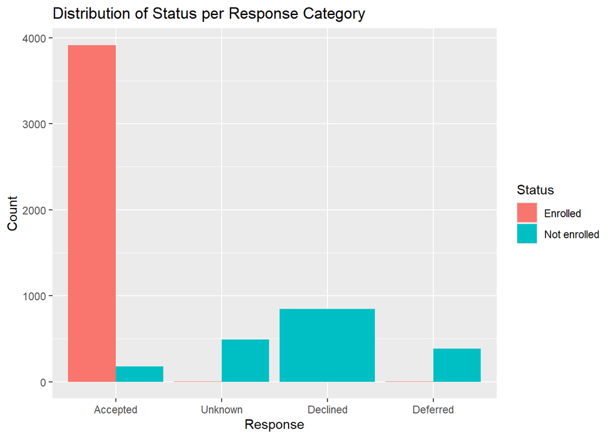

```r
# Status and Response
ggplot(offers_analysis, aes(x = Response, fill = Status)) +
  geom_bar(position = "dodge", stat = "count") +
  labs(title = "Distribution of Status per Response Category",
       x = "Response",
       y = "Count")
```

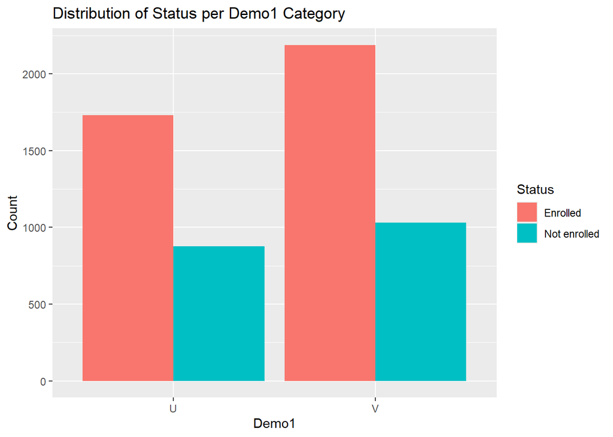

```r
# Status and Demo1
ggplot(offers_analysis, aes(x = Demo1, fill = Status)) +
  geom_bar(position = "dodge", stat = "count") +
  labs(title = "Distribution of Status per Demo1 Category",
       x = "Demo1",
       y = "Count")
```

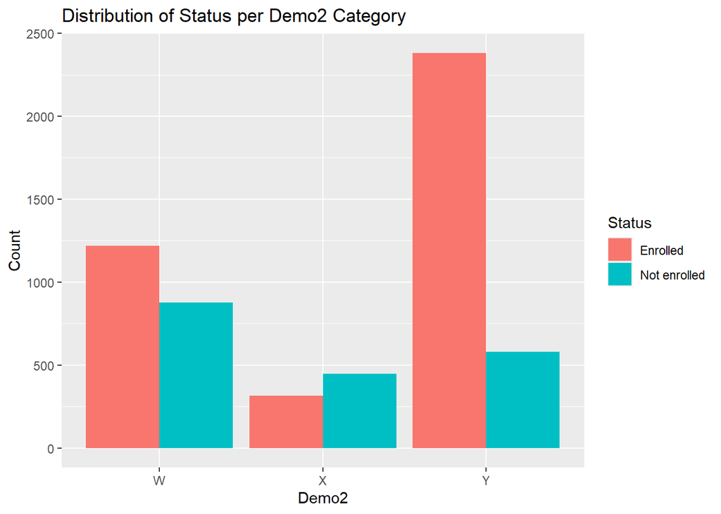

```r
# Status and Demo2
ggplot(offers_analysis, aes(x = Demo2, fill = Status)) +
  geom_bar(position = "dodge", stat = "count") +
  labs(title = "Distribution of Status per Demo2 Category",
       x = "Demo2",
       y = "Count")
```

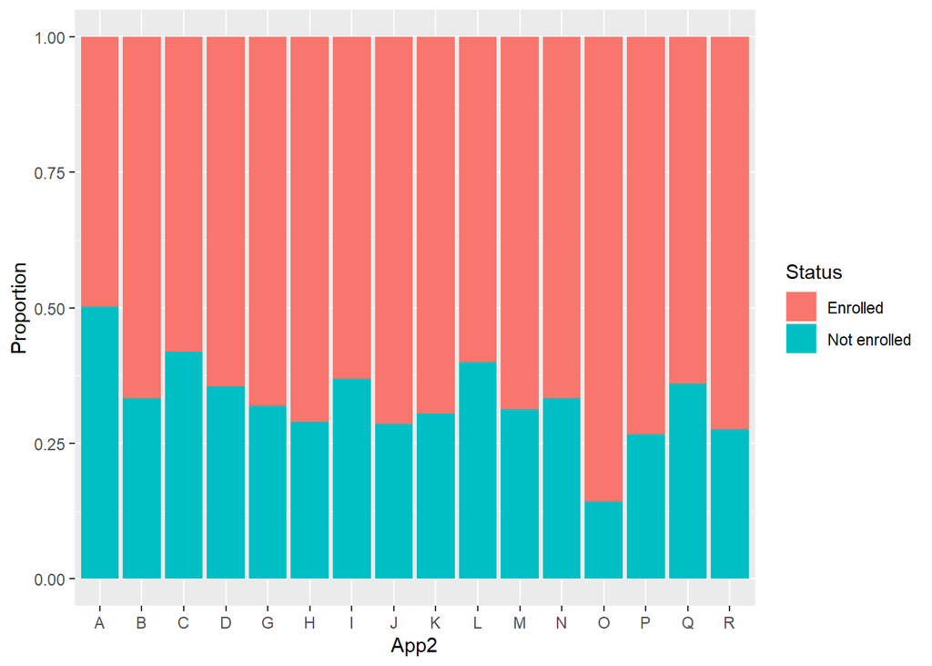

```r
# Status and App2
ggplot(offers_analysis, aes(x = App2, fill = Status)) +
  geom_bar(position = "fill", stat = "count") +
  labs(x = "App2",
       y = "Proportion")
```

# V. Machine Learning Model I: LASSO Regression

```r
# set the seed number so that the results are reproducible
set.seed(420)

# 10-folds cross-validation
cv_folds <- vfold_cv(offers_analysis, v = 10, strata = "Status")

# specify the metrics of interest
class_metrics <- metric_set(f_meas, roc_auc, sensitivity, specificity)
```

## 1. The Recipe

I first need to define the recipe for the LASSO model. The components of the recipe include:

- recipe(Status ~ ., data = offers_analysis): The dependent variable is Status. The dot . means that the rest of the variables are selected as the independent variables. Since I am training the model so I will be using the analysis set (a more traditional name is the training set).
- update_role(AppYear, AppDate, OfferDate, ResponseDate, new_role = “metadata”): Some variables might not be that important so I remove them out of the recipe by changing their role to metadata.
- step_dummy(all_nominal_predictors()): Subsequently, I convert all nominal variables to dummy variable.
- step_normalize(all_predictors()): I normalize all of the variables so that they have mean 0 and standard deviation 1.
- step_downsample(Status): As I have discovered during the EDA, the dependent variable is imbalanced. Therefore, to address this issue, I use the downsampling method to downsample the majority class (“Enrolled”) to match the size of the minority class (“Not enrolled”). The obvious drawback of this method is that I am only using a portion of the analysis dataset.

```r
# define the recipe
lasso_recipe <-
  recipe(Status ~ ., data = offers_analysis) |>
  # remove the variables that will not be used
  update_role(AppYear, AppDate, OfferDate, ResponseDate, new_role = "metadata") |>
  # convert all nominal variables to dummy variables
  step_dummy(all_nominal_predictors()) |>
  step_zv(all_predictors()) |>
  # normalize the variables to have mean 0 and standard deviation 1
  step_normalize(all_predictors()) |>
  # downsample to balance the classes in the dependent variable
  step_downsample(Status)
```

## 2. The Model and The Workflow

The components of the model include:

- penalty = tune(): This setting means that the penalty term, which is a hyperparameter, is to be optimized by R during tuning.
- mixture = 1: This setting means that I am using a logistic regression model with LASSO regularization.

The workflow combines the recipe (lasso_recipe) and the model (lasso_model) into a unified pipeline for streamlined training and evaluation.

```r
lasso_model <-
  logistic_reg(penalty = tune(), mixture = 1) |>
  set_engine("glmnet")

lasso_workflow <-
  workflow() |>
  add_recipe(lasso_recipe) |>
  add_model(lasso_model)
```

## 3. The Tuning Grid

- penalty(c(-3, -1), trans = log10_trans()): specifies the range for the penalty term (or lambda) on a log10 scale.
- levels = 30: divides the range into 30 levels for testing.

```r
grid_lasso <- grid_regular(penalty(c(-3, -1), trans = log10_trans()),
                           levels = 30)
grid_lasso
```

```
## # A tibble: 30 × 1
##    penalty
##      <dbl>
##  1 0.001
##  2 0.00117
##  3 0.00137
##  4 0.00161
##  5 0.00189
##  6 0.00221
##  7 0.00259
##  8 0.00304
##  9 0.00356
## 10 0.00418
## # ℹ 20 more rows
```

## 4. Model Tunning

```r
# set the seed number so that the results are reproducible
set.seed(420)

lasso_tune <-
  lasso_workflow |>
  tune_grid(
    resamples = cv_folds,
    grid = grid_lasso,
    metrics = class_metrics)
```

## 5. Plot The Results

I visualize the performance metrics against the penalty values. This helps me identify the optimal penalty value where the model performs best.

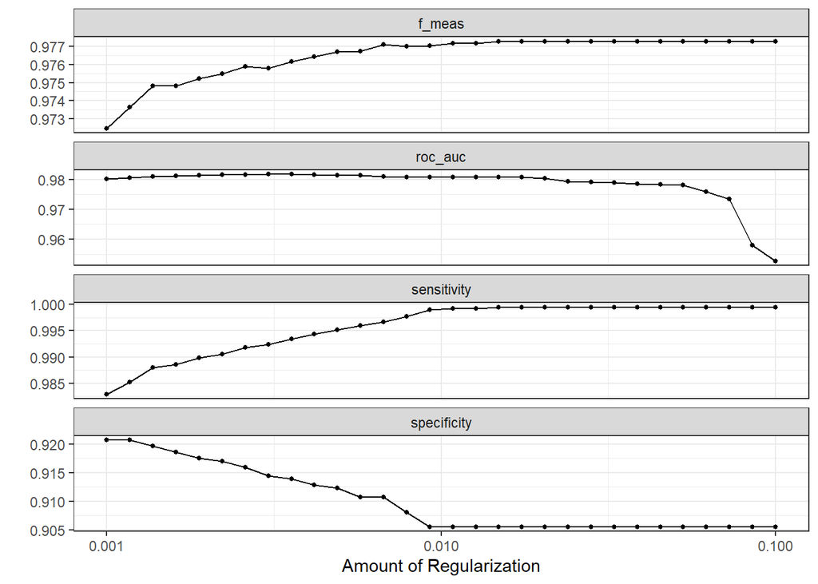

```r
lasso_tune |>
  autoplot() +
  theme_bw()
```

## 6. Collect The Metrics

I use the function collect_metrics() to extract the performance metrics for all combinations of penalty values tested during tuning. My main metric of interest is the F1 score as it balances precision and recall. Therefore, I also create a plot of the F1 score with confidence intervals for each penalty value. The function scale_x_log10() displays the penalty on a logarithmic scale.

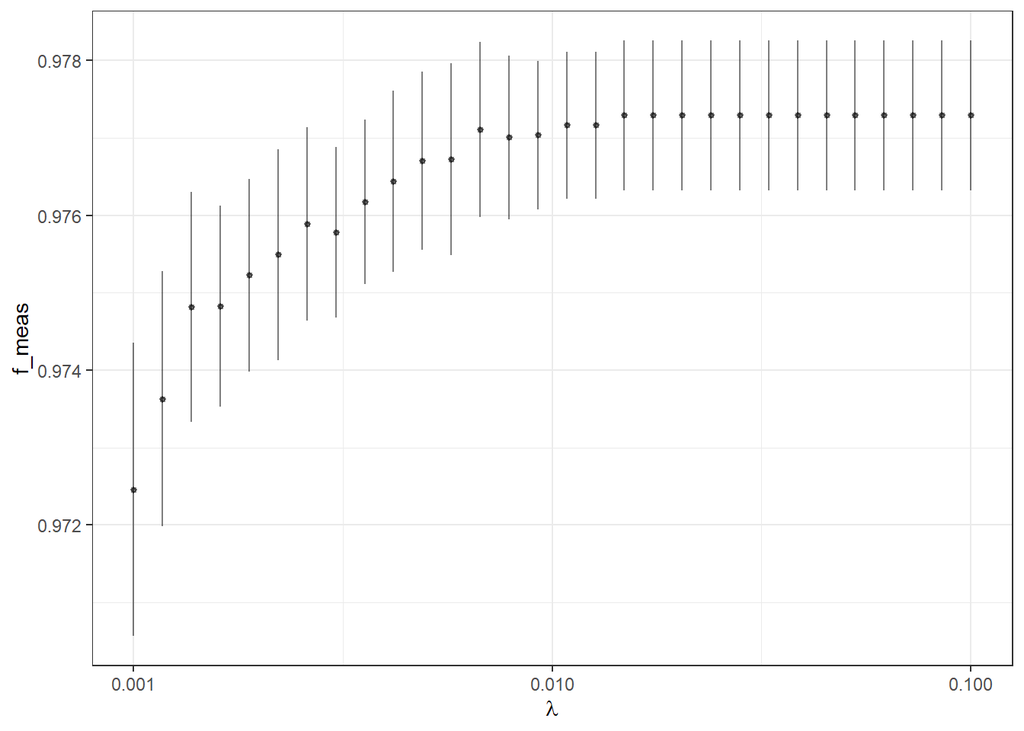

```r
# collect the metrics
lasso_tune_metrics <-
  lasso_tune |>
  collect_metrics()

# plot the f_meas
lasso_tune_metrics |>
  filter(.metric == "f_meas") |>
  ggplot(aes(
    x = penalty, y = mean,
    ymin = mean - std_err, ymax = mean + std_err
  )) +
  geom_pointrange(alpha = 0.5, size = .125) +
  scale_x_log10() +
  labs(y = "f_meas", x = expression(lambda)) +
  theme_bw()
```

## 7. Show The Best Models

```r
lasso_tune |>
  show_best(metric = "f_meas")
```

```
## # A tibble: 5 × 7
##   penalty .metric .estimator  mean     n  std_err .config
##     <dbl> <chr>   <chr>      <dbl> <int>    <dbl> <chr>
## 1  0.0149 f_meas  binary     0.977    10 0.000965 Preprocessor1_Model18
## 2  0.0174 f_meas  binary     0.977    10 0.000965 Preprocessor1_Model19
## 3  0.0204 f_meas  binary     0.977    10 0.000965 Preprocessor1_Model20
## 4  0.0240 f_meas  binary     0.977    10 0.000965 Preprocessor1_Model21
## 5  0.0281 f_meas  binary     0.977    10 0.000965 Preprocessor1_Model22
```

## 8. Choose The Best Model and Finalize The Workflow

I choose the best model using the one standard error rule. Subsequently, I combine the best model and the recipe into a finalized workflow for deployment.

```r
lasso_1se_model <-
  lasso_tune |>
  select_by_one_std_err(metric = "f_meas", desc(penalty))

lasso_1se_model
```

```
## # A tibble: 1 × 2
##   penalty .config
##     <dbl> <chr>
## 1     0.1 Preprocessor1_Model30
```

```r
lasso_workflow_tuned <-
  lasso_workflow |>
  finalize_workflow(lasso_1se_model)

lasso_workflow_tuned
```

```
## ══ Workflow ════════════════════════════════════════════════════════════════════
## Preprocessor: Recipe
## Model: logistic_reg()
##
## ── Preprocessor ────────────────────────────────────────────────────────────────
## 4 Recipe Steps
##
## • step_dummy()
## • step_zv()
## • step_normalize()
## • step_downsample()
##
## ── Model ───────────────────────────────────────────────────────────────────────
## Logistic Regression Model Specification (classification)
##
## Main Arguments:
##   penalty = 0.1
##   mixture = 1
##
## Computational engine: glmnet
```

## 9. Evaluate The Model On The Assessment Set

Finally, I fit the finalized workflow on the full analysis set and evaluate it on the assessment set. The F1 score is the main metric of interest because it balances precision and recall, making it particularly useful when the class distribution is imbalanced. The value of the F1 score is 96.83%. This high value suggests that the model performs well in identifying both enrolled and not-enrolled cases without over-emphasizing either precision or recall.

It can also be seen that the model has high values for Sensitivity, Specificity, and ROC_AUC. The high Sensitivity indicates that most enrolled students are accurately classified. The high Specificity demonstrates that the model rarely misclassifies students as enrolled when they are not. Finally, the high ROC_AUC indicates that the model has excellent discriminatory power.

```r
# fit the model to the entire analysis set and evaluate the model on the assessment set
lasso_last_fit <-
  lasso_workflow_tuned |>
  last_fit(analysis_assessment_split, metrics = class_metrics)

# collect the metrics on the assessment set
lasso_test_metrics <-
  lasso_last_fit |>
  collect_metrics()

lasso_test_metrics
```

```
## # A tibble: 4 × 4
##   .metric     .estimator .estimate .config
##   <chr>       <chr>          <dbl> <chr>
## 1 f_meas      binary         0.968 Preprocessor1_Model1
## 2 sensitivity binary         0.945 Preprocessor1_Model1
## 3 specificity binary         0.989 Preprocessor1_Model1
## 4 roc_auc     binary         0.967 Preprocessor1_Model1
```

# V. Machine Learning Model II: Random Forest

In this section, I train a Random Forest model. Random Forest is an ensemble learning method that uses multiple decision trees and aggregates their results to improve predictive accuracy and control overfitting. This model uses the same cross-validation folds (cv_folds) and performance metrics (class_metrics) as the LASSO model.

## 1. The Recipe

The components of the recipe include:

- recipe(Status ~ ., data = offers_analysis): The dependent variable is Status. The dot . means that the rest of the variables are selected as the independent variables. Since I am training the model so I will be using the analysis set (a more traditional name is the training set).
- update_role(AppDate, OfferDate, AppYear, ResponseDate, HowFirstHeard, new_role = “metadata”): Some variables might not be that important so I remove them out of the recipe by changing their role to metadata.

```r
rf_recipe <-
  recipe(Status ~ ., data = offers_analysis) |>
  update_role(AppDate, OfferDate, AppYear, ResponseDate, HowFirstHeard, new_role = "metadata")
```

## 2. The Model and The Workflow

The components of the model include:

- mtry = tune(): The number of variables to consider for splitting at each node. This hyperparameter is to be tuned by R.
- trees = 50: The number of trees.
- rand_forest(): Specifies a Random Forest model.
- set_mode(“classification”): Sets the model’s objective as classification.
- set_engine(“ranger”, importance = “permutation”): Uses the ranger package for efficient Random Forest implementation and computes variable importance using permutation.

The workflow integrates the recipe (rf_recipe) and the model (rf_model_tune).

```r
rf_model_tune <-
  rand_forest(mtry = tune(), trees = 50) |>
  set_mode("classification") |>
  set_engine("ranger", importance = "permutation")

rf_tune_wf <-
  workflow() |>
  add_recipe(rf_recipe) |>
  add_model(rf_model_tune)
```

## 3. The Tuning Grid

A tuning grid is defined for the mtry hyperparameter which controls the number of variables considered at each tree split. In this case, I create a grid with 12 equally spaced values for mtry ranging from 1 to 12. This grid will be used for hyperparameter tuning during cross_validation.

```r
rf_tune_grid <- grid_regular(mtry(range = c(1, 12)), levels = 12)
rf_tune_grid
```

```
## # A tibble: 12 × 1
##     mtry
##    <int>
##  1     1
##  2     2
##  3     3
##  4     4
##  5     5
##  6     6
##  7     7
##  8     8
##  9     9
## 10    10
## 11    11
## 12    12
```

## 4. Model Tunning

```r
num_cores <- parallel::detectCores()
num_cores
```

```
## [1] 8
```

```r
doParallel::registerDoParallel(cores = num_cores - 1L)

set.seed(420)
rf_tune_res <- tune_grid(
  rf_tune_wf,
  resamples = cv_folds,
  grid = rf_tune_grid,
  metrics = class_metrics)
```

## 5. Show The Best Models

For each of the metrics (F1 score, Sensitivity, and Specificity), the five best models are identified.

- By Sensitivity: Shows the models with the highest ability to correctly identify positive cases (enrolled students).
- By Specificity: Shows the models with the highest ability to correctly identify negative cases (not enrolled students).
- By F1 score: Shows the models with the highest ability to correctly identify both the positive and negative cases (balance precision and recall).

```r
# by f1 score
rf_tune_res |>
  show_best(metric = "f_meas", n = 5) |>
  arrange(desc(mtry))
```

```
## # A tibble: 5 × 7
##    mtry .metric .estimator  mean     n  std_err .config
##   <int> <chr>   <chr>      <dbl> <int>    <dbl> <chr>
## 1     9 f_meas  binary     0.977    10 0.000885 Preprocessor1_Model09
## 2     7 f_meas  binary     0.977    10 0.00108  Preprocessor1_Model07
## 3     4 f_meas  binary     0.977    10 0.000759 Preprocessor1_Model04
## 4     3 f_meas  binary     0.977    10 0.000986 Preprocessor1_Model03
## 5     2 f_meas  binary     0.978    10 0.000829 Preprocessor1_Model02
```

```r
# by sensitivity
rf_tune_res |>
  show_best(metric = "sensitivity", n = 5) |>
  arrange(desc(mtry))
```

```
## # A tibble: 5 × 7
##    mtry .metric     .estimator  mean     n  std_err .config
##   <int> <chr>       <chr>      <dbl> <int>    <dbl> <chr>
## 1     5 sensitivity binary     0.996    10 0.00114  Preprocessor1_Model05
## 2     4 sensitivity binary     0.997    10 0.00108  Preprocessor1_Model04
## 3     3 sensitivity binary     0.997    10 0.00108  Preprocessor1_Model03
## 4     2 sensitivity binary     0.999    10 0.000544 Preprocessor1_Model02
## 5     1 sensitivity binary     0.999    10 0.000340 Preprocessor1_Model01
```

```r
# by specificity
rf_tune_res |>
  show_best(metric = "specificity", n = 5) |>
  arrange(desc(mtry))
```

```
## # A tibble: 5 × 7
##    mtry .metric     .estimator  mean     n std_err .config
##   <int> <chr>       <chr>      <dbl> <int>   <dbl> <chr>
## 1    12 specificity binary     0.914    10 0.00370 Preprocessor1_Model12
## 2    11 specificity binary     0.914    10 0.00316 Preprocessor1_Model11
## 3     9 specificity binary     0.915    10 0.00341 Preprocessor1_Model09
## 4     8 specificity binary     0.914    10 0.00351 Preprocessor1_Model08
## 5     7 specificity binary     0.914    10 0.00362 Preprocessor1_Model07
```

## 6. Plot The Results

The F1 score starts lower at very small values of mtry and stabilizes at higher values of mtry (around 3 or more). This indicates that using too few predictors (mtry) results in suboptimal model performance.

Sensitivity is highest when mtry is small but decreases steadily as mtry increases. A small mtry allows the model to better identify true positives (enrolled students). However, increasing mtry reduces Sensitivity, likely because the trees become less flexible in capturing positive cases.

Specificity is lowest for very small mtry values but improves rapidly and stabilizes at higher values of mtry. A low mtry results in many false positives, leading to lower Specificity. Increasing mtry improves the model’s ability to correctly identify true negatives (students not enrolled).

The error bars represent the variability (standard error) of each metric across cross-validation folds. The error bars for Sensitivity are slightly wider for larger mtry values, indicating more variability in the model’s ability to capture true positives at those settings. F1 score and Specificity have relatively small error bars, suggesting consistent performance across folds.

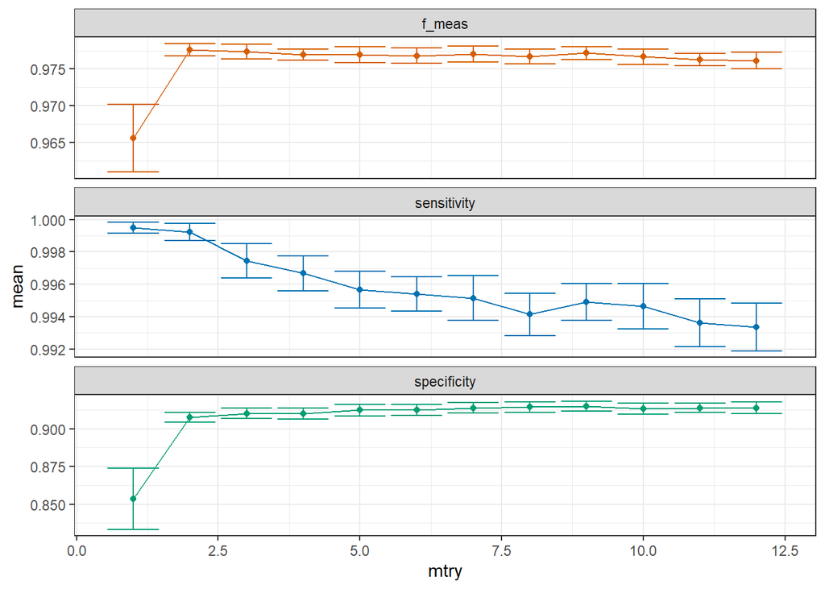

```r
rf_tune_res |>
  collect_metrics() |>
  filter(.metric %in% c("specificity", "f_meas", "sensitivity")) |>
  ggplot(aes(
    x = mtry, y = mean, ymin = mean - std_err,
    ymax = mean + std_err, colour = .metric
  )) +
  geom_errorbar() +
  geom_line() +
  geom_point() +
  scale_colour_manual(values = c("#D55E00", "#0072B2", "#009E73")) +
  facet_wrap(~.metric, ncol = 1, scales = "free_y") +
  guides(colour = "none") +
  theme_bw()
```

## 7. Choose The Best Model and Finalize The Workflow

I choose the best model using the F1 score. Subsequently, I combine the best model and the recipe into a finalized workflow for deployment. As expected, the best model has a value of 2 for mtry.

```r
best_rf <- select_best(rf_tune_res, metric = "f_meas")

rf_workflow_tuned <-
  rf_tune_wf |>
  finalize_workflow(best_rf)

rf_workflow_tuned
```

```
## ══ Workflow ════════════════════════════════════════════════════════════════════
## Preprocessor: Recipe
## Model: rand_forest()
##
## ── Preprocessor ────────────────────────────────────────────────────────────────
## 0 Recipe Steps
##
## ── Model ───────────────────────────────────────────────────────────────────────
## Random Forest Model Specification (classification)
##
## Main Arguments:
##   mtry = 2
##   trees = 50
##
## Engine-Specific Arguments:
##   importance = permutation
##
## Computational engine: ranger
```

## 8. Evaluate The Model On The Assessment Set

Finally, I fit the finalized workflow on the full analysis set and evaluate it on the assessment set. The F1 score is the main metric of interest because it balances precision and recall, making it particularly useful when the class distribution is imbalanced. The value of the F1 score is 96.72%. This high value suggests that the model performs well in identifying both enrolled and not-enrolled cases without over-emphasizing either precision or recall.

It can also be seen that the model has high values for Sensitivity, Specificity, and ROC_AUC. The high Sensitivity indicates that most enrolled students are accurately classified. The high Specificity demonstrates that the model rarely misclassifies students as enrolled when they are not. Finally, the high ROC_AUC indicates that the model has excellent discriminatory power.

```r
# fit the model to the entire analysis set and evaluate the model on the assessment set
rf_final_fit <-
  rf_workflow_tuned |>
  last_fit(analysis_assessment_split, metrics = class_metrics)

# collect the metrics on the assessment set
rf_test_results <-
  rf_final_fit |>
  collect_metrics()

rf_test_results
```

```
## # A tibble: 4 × 4
##   .metric     .estimator .estimate .config
##   <chr>       <chr>          <dbl> <chr>
## 1 f_meas      binary         0.967 Preprocessor1_Model1
## 2 sensitivity binary         0.943 Preprocessor1_Model1
## 3 specificity binary         0.989 Preprocessor1_Model1
## 4 roc_auc     binary         0.982 Preprocessor1_Model1
```

# VI. Evaluation Of The Performance Of The Two Models On The Assessment Set

```r
lasso_test_metrics
```

```
## # A tibble: 4 × 4
##   .metric     .estimator .estimate .config
##   <chr>       <chr>          <dbl> <chr>
## 1 f_meas      binary         0.968 Preprocessor1_Model1
## 2 sensitivity binary         0.945 Preprocessor1_Model1
## 3 specificity binary         0.989 Preprocessor1_Model1
## 4 roc_auc     binary         0.967 Preprocessor1_Model1
```

```r
rf_test_results
```

```
## # A tibble: 4 × 4
##   .metric     .estimator .estimate .config
##   <chr>       <chr>          <dbl> <chr>
## 1 f_meas      binary         0.967 Preprocessor1_Model1
## 2 sensitivity binary         0.943 Preprocessor1_Model1
## 3 specificity binary         0.989 Preprocessor1_Model1
## 4 roc_auc     binary         0.982 Preprocessor1_Model1
```

Next, I fit the finalized workflow of the LASSO model on the final training set and evaluate it on the censored prediction set. The warnings “No event observations were detected in truth with event level ‘Enrolled’” and “There were issues with some computations” are expected, and occur only because the value of Status has been set to NA for AY2023 (this is because I am using the censored prediction set).

```r
metric <- metric_set(roc_auc)

final_model <-
  lasso_workflow_tuned |>
  last_fit(final_training_prediction_split, metrics = metric)
```

```
## → A | warning: No event observations were detected in `truth` with event level 'Enrolled'.
```

```
## There were issues with some computations   A: x1There were issues with some computations   A: x1
```

Having fit the final model, I need to generate predictions for each program, specifically:

- 1. The total number of students (among the offers sent prior to March 15, 2023) who will attend (hard predictions), and
- 2. The average probability (among the offers sent prior to March 15, 2023) of enrollment (soft prediction).

I use a decision threshold of 0.5 for the hard predictions.

```r
final_model |>
  augment() |>
  group_by(Program) |>
  summarise(
    Predicted_N = sum(.pred_Enrolled >= .5),
    Predicted_Prob = mean(.pred_Enrolled)
  )
```

```
## # A tibble: 11 × 3
##    Program   Predicted_N Predicted_Prob
##    <fct>           <int>          <dbl>
##  1 MScBA-AFM          47          0.503
##  2 MScBA-BAM         146          0.566
##  3 MScBA-MIM          54          0.468
##  4 MScBIM             82          0.591
##  5 MScFI             404          0.594
##  6 MScGBS             77          0.556
##  7 MScMI              28          0.538
##  8 MScMM             112          0.580
##  9 MScSCM             48          0.561
## 10 MScSE              34          0.578
## 11 MScSM             283          0.613
```

# VII. Compare The Predicted Results With The Actual Results

I now load the uncensored dataset, which contains the actual values for the Status column for AY2023 observations

```r
# load the uncensored dataset
load("./offers_uncensored.RData")
```

Again, I create the final training set and the prediction set. The prediction set includes AY2023 observations that were available before 2023-03-15. On the other hand, the final training set includes all of observations from AY2020-AY2022.

```r
set.seed(420)
final_training_prediction_split <-
  offers |>
  make_appyear_split(test_year = 2023)

training(final_training_prediction_split) |> years_and_max_dates()
```

```
## # A tibble: 3 × 6
##   AppYear `Num observations` `Max \`AppDate\`` `Max \`OfferDate\``
##     <int>              <int> <date>            <date>
## 1    2020               2835 2020-07-20        2020-09-23
## 2    2021               2986 2021-06-18        2021-08-30
## 3    2022               2950 2022-06-08        2022-09-08
## # ℹ 2 more variables: `Max \`ResponseDate\`` <date>,
## #   `\`ResponseDate\` is NA` <int>
```

```r
testing(final_training_prediction_split) |> years_and_max_dates()
```

```
## # A tibble: 1 × 6
##   AppYear `Num observations` `Max \`AppDate\`` `Max \`OfferDate\``
##     <int>              <int> <date>            <date>
## 1    2023               2069 2023-03-01        2023-03-14
## # ℹ 2 more variables: `Max \`ResponseDate\`` <date>,
## #   `\`ResponseDate\` is NA` <int>
```

```r
offers_final_training <- training(final_training_prediction_split)
offers_prediction <- testing(final_training_prediction_split)
```

Next, I fit the finalized workflow of the LASSO model on the final training set and evaluate it on the uncensored prediction set.

```r
final_model_uncensored <-
  lasso_workflow_tuned |>
  last_fit(final_training_prediction_split, metrics = class_metrics)
```

I compare the predicted Status with the actual Status for each observation.

```r
final_model_uncensored_aug <-
  final_model_uncensored |>
  augment()
final_model_uncensored_aug
```

```
## # A tibble: 2,069 × 21
##    .pred_class  .pred_Enrolled `.pred_Not enrolled` Status       AppYear Program
##    <fct>                 <dbl>                <dbl> <fct>          <int> <fct>
##  1 Enrolled              0.742                0.258 Enrolled        2023 MScBA-…
##  2 Enrolled              0.742                0.258 Enrolled        2023 MScBA-…
##  3 Enrolled              0.742                0.258 Enrolled        2023 MScBA-…
##  4 Enrolled              0.742                0.258 Enrolled        2023 MScBA-…
##  5 Enrolled              0.742                0.258 Enrolled        2023 MScBA-…
##  6 Not enrolled          0.290                0.710 Not enrolled    2023 MScBA-…
##  7 Enrolled              0.742                0.258 Enrolled        2023 MScBA-…
##  8 Enrolled              0.742                0.258 Enrolled        2023 MScBA-…
##  9 Not enrolled          0.290                0.710 Not enrolled    2023 MScBA-…
## 10 Enrolled              0.742                0.258 Enrolled        2023 MScBA-…
## # ℹ 2,059 more rows
## # ℹ 15 more variables: AppDate <date>, OfferDate <date>, ResponseDate <date>,
## #   Response <fct>, Demo1 <fct>, Demo2 <fct>, Demo3 <fct>, Edu1 <fct>,
## #   Edu2 <fct>, Edu3 <fct>, App1 <fct>, App2 <fct>, App3 <fct>, App4 <int>,
## #   HowFirstHeard <fct>
```

I find the F1 score of the model. The value of the F1 score is 98.46%. This high value suggests that the model performs well in identifying both enrolled and not-enrolled cases without over-emphasizing either precision or recall.

Also, I create two confusion matrices. The first one has a decision threshold of 0.5 while the second one has a decision threshold of 0.65. In both cases, the results are the same. The model misclassifies only 1 not enrolled case and 40 enrolled cases.

```r
# find the F1_score
primary_metric <- metric_set(f_meas)
final_model_uncensored_aug |>
  primary_metric(truth = Status, estimate = .pred_class)
```

```
## # A tibble: 1 × 3
##   .metric .estimator .estimate
##   <chr>   <chr>          <dbl>
## 1 f_meas  binary         0.985
```

```r
# create the confusion matrix (threshold 0.5)
final_model_uncensored_aug |>
  conf_mat(truth = Status, estimate = .pred_class)
```

```
##               Truth
## Prediction     Enrolled Not enrolled
##   Enrolled         1314            1
##   Not enrolled       40          714
```

```r
# create the confusion matrix (threshold 0.65)
final_model_uncensored_aug |>
  mutate(.pred_class_65 = factor(ifelse(.pred_Enrolled >= 0.65, "Enrolled", "Not enrolled"))) |>
  conf_mat(truth = Status, estimate = .pred_class_65)
```

```
##               Truth
## Prediction     Enrolled Not enrolled
##   Enrolled         1314            1
##   Not enrolled       40          714
```